[figure not shown]

# Final Project "prosper.com"

**Prosper likes to promote the fact that every investor since 2009 (Prosper 2.0) that has invested in at least 100 loans has made a positive return.** (Source: https://www.lendacademy.com/prosper-review/)

The interpretation of the sentence is a bit tricky: Does it mean at least one loan got a positive return while the rest got lost or returned less than invested? Or is the total return adressed? What if we take the 100 worst loans, is there still a positive return?

To get out of this ambiguity we take a simpler question. Instead of asking: What to do to maximize returns - we take a more defensive approach. What shall an investor do to avoid losses? In time of zero interest rates provided by banks we consider an positive return already as achievement.

- We want to know which type of loan is least likely to default. Since everything is changing constantly we need to investigate the distribution of loan types over time to get a feeling for trends and further evolution.
- We also look at the geographic distribution of loans and their liklyhood to default.
- The combination of default rates for loan category with the geographic default risk is our first rule of thumb as aspiring investors.

## 1. How trust worthy are borrowers?

To the 83.982 listed loans in the investigated dataset 68989 borrowers are associated. Most borrowers have good to medium prosper ratings (A to D). We would expect borrowers with high scores to be exceptional trust worthy. So among these borrowers debt rate shouldn't be higher than 100%. Is it like this?

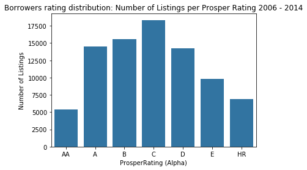

```python
sb.countplot(data=df_loan, x='ProsperRating (Alpha)',
             color=blue,
             order=prosper_rating_categories);
plt.ylabel('Prosper Rating');
plt.ylabel('Number of Listings');
plt.title('Borrowers rating distribution: Number of Listings per Prosper Rating 2006 - 2014');
```

### Before 2009

Before 2009 borrowers with debt income ratio above 100% were normally distributed across the credit grades. This means a part of them unless highly indebted got very good and good credit grades. The credit grade was misleading in that cases.

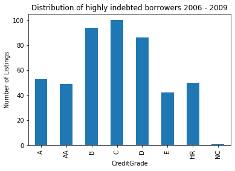

```python
barplot = df_indebted_distribution_grades.plot(kind='bar',
                                              title='Distribution of highly indebted borrowers 2006 - 2009',
                                              legend=False);
barplot.set_ylabel('Number of Listings');
```

### After 2009

After the financial crisis 2008-2009 the ratings got better and are now more trust worthy. Nevertheless thereare still some black sheeps among them.

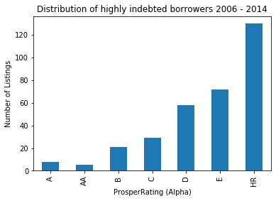

```python
barplot = df_indebted_distribution_scores.plot(kind='bar',
                                              title='Distribution of highly indebted borrowers 2006 - 2014',
                                              legend=False);
barplot.set_ylabel('Number of Listings');
```

## 2. How does the borrowers rating evolve over time (2009- 2014)?

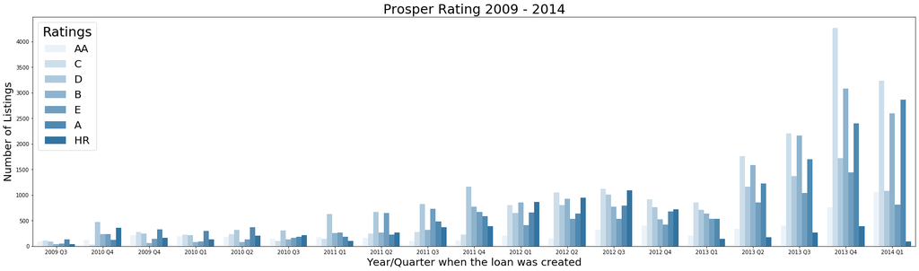

```python
df_loan_2009 = df_loan_2009.sort_values(['ListingCreationDate'])
plt.figure(figsize=(30,8))
ax = sb.countplot(x="LoanOriginationQuarterNew",
                  hue="ProsperRating (Alpha)",
                  color=blue,
                  data=df_loan_2009);
plt.xlabel('Year/Quarter when the loan was created', fontsize=20);
plt.ylabel('Number of Listings', fontsize=20);
plt.title('Prosper Rating 2009 - 2014', fontsize=25);
plt.legend(loc='upper left',fontsize=20, title='Ratings', title_fontsize=25);
```

## 3. What are borrowers taking loans for?

- Over 50.000 loans are given for debt consolidation, that is the most common reason fpr taking a loan.
- Around 9.000 loans are taken for bying cars, over 6.000 for home improvements, 5.000 for business purposes and around 2.000 for students needs.

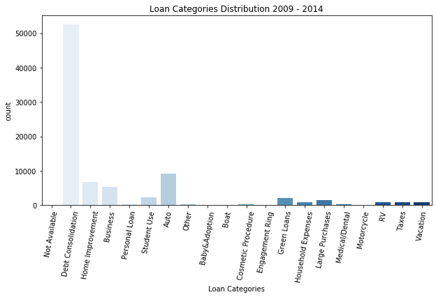

```python
plt.figure(figsize = [10, 5]);
cp = sb.countplot(data=df_loan_2009,
                  x='ListingCategory (numeric)',
                  palette=sb.color_palette("Blues", 20));
cp.set_xticklabels(listing_categories);
plt.xticks(rotation=80);
cp.set_xlabel('Loan Categories')
cp.set_title('Loan Categories Distribution 2009 - 2014');
```

## 4. How do loan categories evolve over time?

Highest amount of listings go to debt consolidation, in 2013 over 10 times more than 2010 - do the borowers turn to the prosper loan platform if the can not get loans from banks anymore?

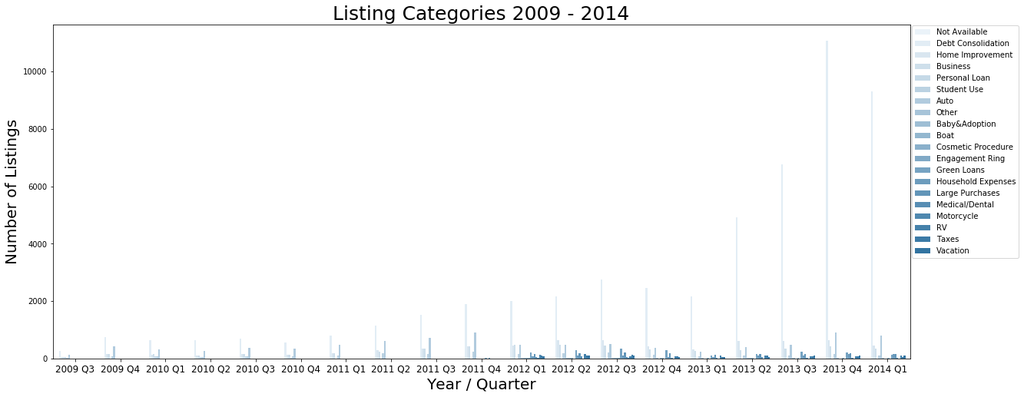

```python
plt.figure(figsize = [20, 8]);
plot_loan_catgeories_over_time(df_loan_2009,
                               listing_categories,
                               loan_org_quarter_categories,
                              'Listing Categories 2009 - 2014');
```

Until end of 2011 loans felt mainly in 4 categories: Home Improvement, Business, Student Use and Auto Highest Positon here got the loans for cars

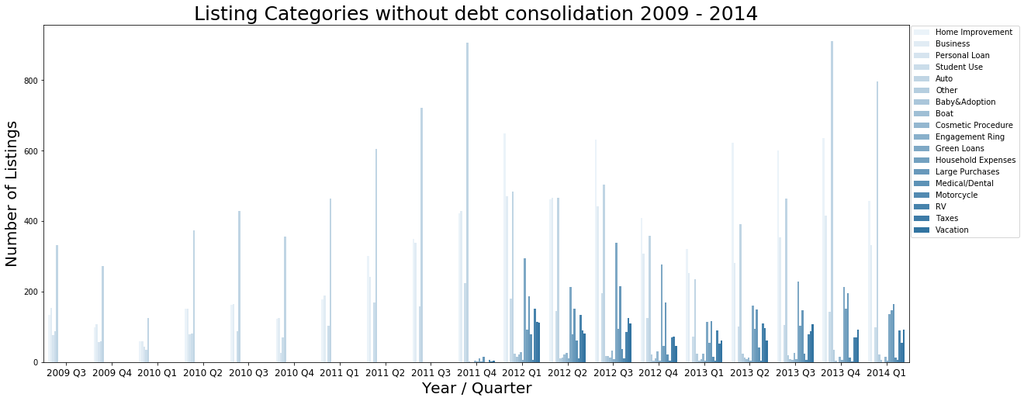

```python
plt.figure(figsize = [20, 8]);
plot_loan_catgeories_over_time(df_loan_without_debt_2009,
                               listing_categories_without_debt,
                               loan_org_quarter_categories,
                              'Listing Categories without debt consolidation 2009 - 2014');
```

## 5. Which amount of loans are in each category?

### Before 2009

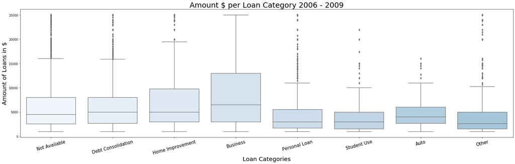

```python
 plot_loan_amounts(df_loan_2006,
                 listing_categories,
                 'Amount $ per Loan Category 2006 - 2009')
```

### After 2009

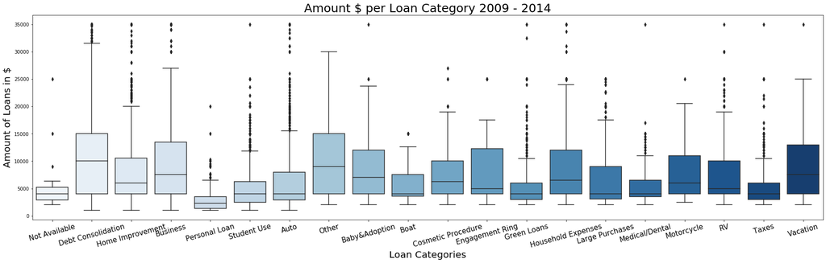

```python
plot_loan_amounts(df_loan_2009,
                 listing_categories,
                 'Amount $ per Loan Category 2009 - 2014')
```

## 6. Which loan categories have most defaults?

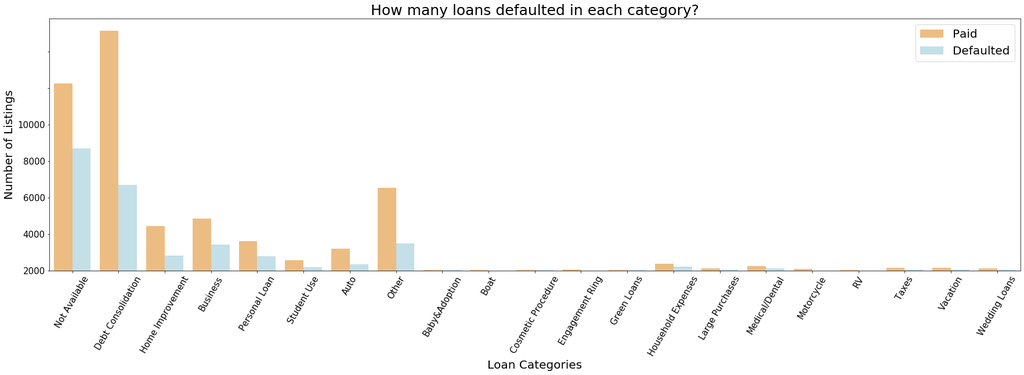

```python
plt.figure(figsize = [30, 8]);
cp = sb.countplot(data=df_loan_with_outcome,
                  x='ListingCategory (numeric)',
                  hue='Loan Outcome',
                  palette=sb.color_palette("RdYlBu", 2)
                 );
cp.set_xticklabels(listing_categories, fontsize=15);
cp.set_yticklabels([2000, 4000, 6000, 8000, 10000], fontsize=15)
plt.xticks(rotation=60);
plt.legend(fontsize=20)
cp.set_xlabel('Loan Categories', fontsize=20);
cp.set_ylabel('Number of Listings', fontsize=20);
cp.set_title('How many loans defaulted in each category?', fontsize=25);
```

## 7. What is the best state and category to invest based on default rate?

Considering only states and categories with at least 10 loans:

If you got one of the 14 business loans in Idaho or one of the 17 home improvement loans in New Hampshire you had no chance for any default. All states with very few loans tend to have low default rates.

If you as an investor turn to states with higher amounts of loans, for instance California with 1675 loans for debt consolidation you have to accept a mean likelyhood of default of 19%.

[figure not shown]

```python
from IPython.utils import io
with io.capture_output() as captured:
    grid = sb.FacetGrid(data=df_loan_with_outcome_categ,
                     col="BorrowerState",
                     hue="Loan Outcome",
                     col_wrap=3,
                     height=5,
                     #aspect =1,
                     sharex=False,
                     sharey=True,
                     legend_out=True,
                     row_order=ordered_states
                    );
    cp = grid.map(sb.countplot, 'ListingCategory (numeric)');
    grid.set_xlabels('Listing Catgeories', fontsize=10);
    grid.set_ylabels('Count', fontsize=20);
    grid.set_xticklabels(listing_categories_short, rotation= 60, fontsize=15);
    grid.set_yticklabels(fontsize=15);
    grid.fig.subplots_adjust(hspace=0.5, wspace=0.2);
    axes = grid.axes.flatten();
    grid.axes[2].legend(fontsize=20);


    for ind, axe in enumerate(axes, start=0):
        state = axe.title.get_text()[16:];
        axe.set_title(states[state], fontsize=25);
        print('len(axe.patches) is: ', len(axe.patches))
        index=0
        print('index is: ', index)
        for aind, p in enumerate(axe.patches, start=0):
            print('aind is: ', aind)
            print('p.get_y() is: ', p.get_y())
            print('p.get_height() is: ', p.get_height())
            x = p.get_x() + p.get_width()/2-0.1;
            y = p.get_y() + p.get_height() + 15.0;
            percentage = index
            try:
                result = df_state_cat_rate.loc[state, (index+1)]
                print('result is: ', result)
                percentage = str(int(result['DefaultRate'])) + ' %';
            except TypeError as e:
                percentage = '0 %'
            print('percentage is: ', percentage)
            axe.annotate(percentage, (x, y), fontsize=15);
            index += 1
            if (index >= len(axe.patches)/2):
                break
```

# Conclusion

**Prosper likes to promote the fact that every investor since 2009 (Prosper 2.0) that has invested in at least 100 loans has made a positive return.** (Source: https://www.lendacademy.com/prosper-review/)

We assume we invest 100 Dollar into 100 different loans on prosper platform - what can we do to achieve a positive return in total?

A good average combination of state and category has a default rate between 20% and 25%.

But what does this mean? From our 100 invested Dollars 20 Dollar will probably be lost. Can the other 80% loans compensate that loss with their returns? For doing so, the successful loans should have a return rate of at least 25%. The maximum return rate for the worst prosper rates is 49%. As per what we saw on prosper.com medium prosper rates hat return rates around 20%. So we really doubt wether will be possible to compensate all losses with acting on medium risk levels.

For investing successfully on prosper.com we not only combine black and white lists. We need a better strategy considering combinations of prosper ratings, state, category and tendencies over time. We could also investigate the impact of other attributes of the borrower like his occupation.